# Lab 14: Summarizing Data

## Birds Data Again

Today we will be working with the birds data once again (and as on Thursday, hopefully allowing time to once again look at Project B):

Here is a full data dictionary describing all of the variables

- **genus** (chr): taxonomic rank of the bird
- **species** (chr): scientific species name of the bird
- **name** (chr): common name of the bird
- **type** (chr): common name of the type of bird
- **egg_mass** (dbl): average mass of an egg when laid (grams)
- **male_mass** (dbl): average observed mass of an adult male (grams)
- **mating_system** (int): scores of mating system. Intensity of male-male competition increases from 1 to 5.
  - 1. polyandry
  - 2. monogamy (<5% polygyny)
  - 3. mostly monogamy, but occasional polygyny (5–15% polygyny)
  - 4. mostly polygyny (> 15% polygyny)
  - 5. lek or promiscuous
- **display** (int): mating display agility
  - 1. ground displays only, including displays on trees and bushes
  - 2. ground displays, but with occasional jumps/leaps into the air
  - 3. both ground and non-acrobatic flight displays
  - 4. mainly aerial displays, non-acrobatic
  - 5. mainly aerial displays, acrobatic
- **resource** (int): scores of territoriality and between-mate resource sharing
  - 0. males and females don’t share resources and they feed away from their breeding territory
  - 1. males and females share resources on their territory only during the breeding season
  - 2. males and females share resources on their territory all year round.
- **clutch_size** (dbl): average number of eggs produced per clutch

## Summarizing the Data

Create a new dataset which summarizes everything to the level of a bird type using the `group_summarize` function:

Create a log-log plot of the median egg mass and median male mass for each bird type.

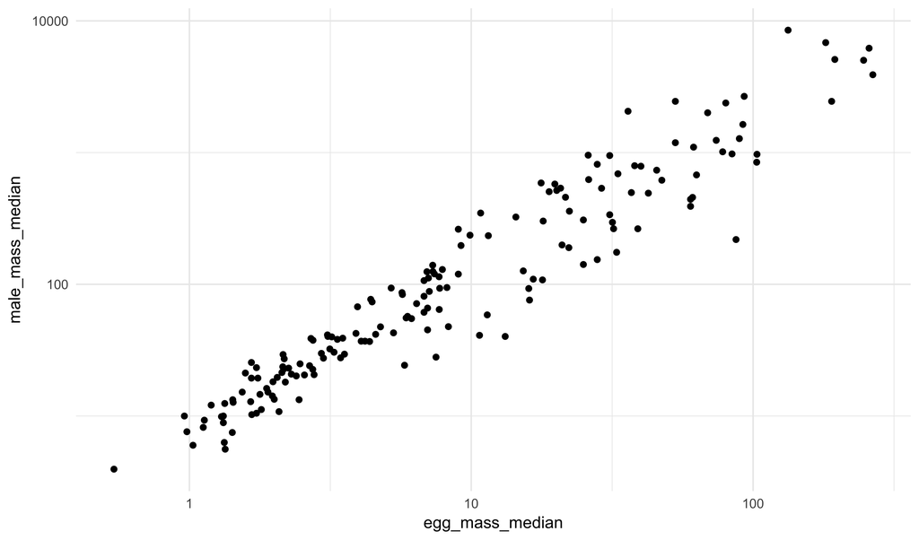

Now create a new dataset filtered to only those bird types with 5 or more birds in the original dataset:

Finally, add two layers to the first plot that (1) colors the smaller set of birds in red and (2) provides a textual label for the red colored points. Try to make the labels readable (hint: perhaps add the `alpha` aesthetic to the first set of points and/or jitter the y-axis of the labels):

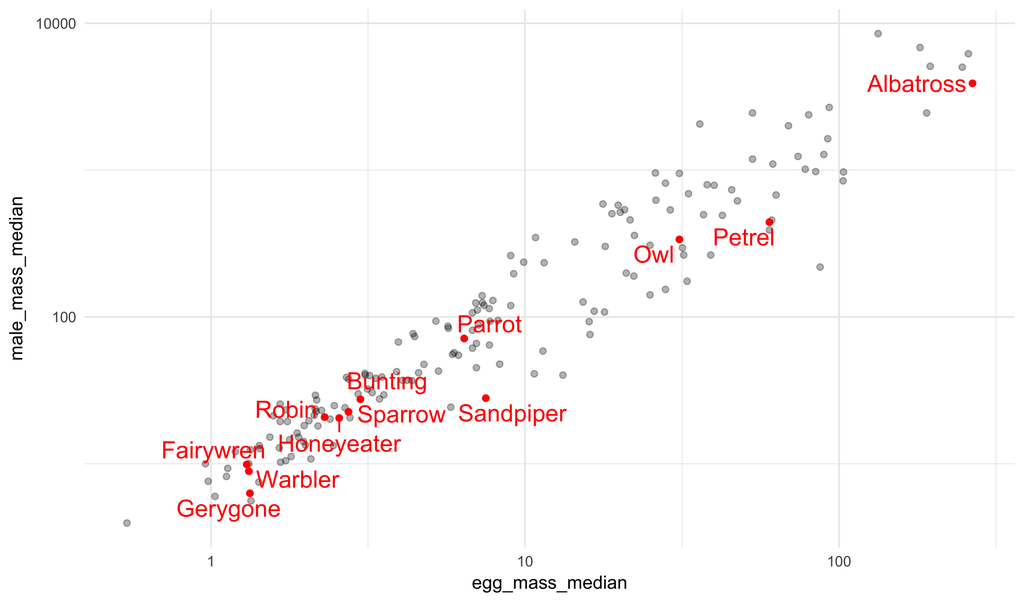